# Loss Functions And Errors

## Contents

1. Imports
2. Classificication
1. TP, FP, FN and TN
2. Accuracy
3. Precision
1. Accuracy And Precision
2. Precision and Recall
4. F1 Score
5. AUC-ROC curve
6. Cross Entropy
3. Regression
1. Mean Absolute Error
2. Mean Squared Error
3. Mean Squared Log Error
4. $R^2$ Score

# Imports

```python
import matplotlib.pyplot as plt
import numpy as np
```

# Classificication

## TP, FP, FN and TN

A **true positive** is an outcome where the model correctly predicts the positive class. Similarly, a **true negative** is an outcome where the model correctly predicts the negative class.

A **false positive** is an outcome where the model incorrectly predicts the positive class. And a **false negative** is an outcome where the model incorrectly predicts the negative class.

Let's make the following definitions:

- "Wolf" is a positive class.
- "No wolf" is a negative class.

[figure not shown]

## Accuracy

Accuracy is defined as: $$ \text{Accuracy} = \frac{\text{Number of correct predictions}}{\text{Number of all predictions}}\\ \text{Accuracy} = \frac{TP + TN}{TP + TN + FP + FN} $$

## Precision

Precision is defined as: $$ \text{Precision} = \frac{\text{Number of true positives}}{\text{Number of true positives} + \text{Number of false positives}}\\ \text{Precision} = \frac{TP}{TP + FP} $$

### Accuracy And Precision

**Accuracy** is how close a measured value is to the actual (true) value.

**Precision** is how close the measured values are to each other.

[figure not shown]

### Precision and Recall

[figure not shown]

In the above image, the precision and recall are 0.8 and 0.73.

In the image below, we have increased the threshold. This results in a lower number of false negative and hence it decreses the recall. and increases precision. The precision and recall are 0.88 and 0.64.

[figure not shown]

On the other hand, in the image below, we have decreased the threshold which increases the number of false negative and hence increases the recall but on the cost of an decrease in precision. The precision and recall in this case are are 0.75 and 0.82.

[figure not shown]

## F1 Score

Since there is a trade-off between precision and recall we can not use a single of them to judge the performance of our model. Due to this, we use the **F1 Score** which is the harmonic mean of precision and recall. That is: $$ \text{F1 Score} = \frac{2 \times \text{Precision} \times \text{Recall}}{\text{Precision} + \text{Recall}} $$

## AUC-ROC curve

An ROC curve (receiver operating characteristic curve) is a graph showing the performance of a classification model at all classification thresholds. This curve plots **false positive rate** (FPR) against **true positive rate** (TPR). TPR is nothing but recall while FPR is defined as: $$ FPR = \frac{FP}{FP + TN} $$

An ROC curve plots TPR vs. FPR at different classification thresholds.

[figure not shown]

An excellent model has AUC near to the 1 which means it has a good measure of separability. A poor model has an AUC near 0 which means it has the worst measure of separability. In fact, it means it is reciprocating the result. It is predicting 0s as 1s and 1s as 0s. And when AUC is 0.5, it means the model has no class separation capacity whatsoever.

## Cross Entropy

Cross-entropy loss, or log loss, measures the performance of a classification model whose output is a probability value between 0 and 1. Cross-entropy loss increases as the predicted probability diverges from the actual label. Mathematically, in binary classification, the cross-entropy loss is defined as: $$ -{(y\log(p) + (1 - y)\log(1 - p))} $$

The cross-entropy penalizes both types of errors, but especially those predictions that are confident and wrong! To see this, we'll plot the cross-entropy for the case when the true label is 1 and the predicted probability is varying.

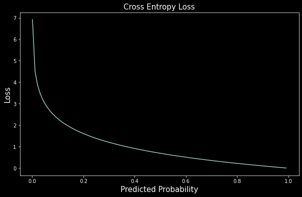

```python
y_true = 1
y_pred = np.arange(0.001, 1, 0.01)

def log_loss(y_true, pred):
    first = y_true * np.log(pred)
    second = (1 - y_true) * np.log(1 - pred)
    return -(first + second)

loss = log_loss(y_true, y_pred)
plt.figure(figsize=(10, 6))
plt.plot(y_pred, loss)
plt.xlabel('Predicted Probability', fontdict={'fontsize': 15})
plt.ylabel('Loss', fontdict={'fontsize': 15})
plt.title('Cross Entropy Loss', fontdict={'fontsize': 15})
plt.show()
```

We can see that the loss increases exponentially as the prediction is wrong and confident.

If $M\gt2$ (i.e. multiclass classification), we calculate a separate loss for each class label per observation and sum the result. $$-\sum_{c=1}^My_{o,c}\log(p_{o,c})$$

# Regression

## Mean Absolute Error

Mean Absolute Error is defined as: $$ MAE = \sum_{i=1}^{n} \frac{|y_i - \hat{y_i}|}{n} $$ Here $y_i$ is the actual value and $\hat{y_i}$ is the predicted value.

## Mean Squared Error

This is defined as: $$ MSE = \sum_{i=1}^{n} \frac{(y_i - \hat{y_i})^2}{n} $$ Here $y_i$ is the actual value and $\hat{y_i}$ is the predicted value.

## Mean Squared Log Error

MSLE is defined as: $$ MSLE = \sum_{i=1}^{n} \frac{(log(y_i + 1) - log(\hat{y_i} + 1))^2}{n}\\ $$ Here $y_i$ is the actual value and $\hat{y_i}$ is the predicted value.

## $R^2$ Score

Simply speaking, $R^2$ score is defined as: $$ R^2 = 1- \frac{RSS}{TSS} $$ Here $RSS$ is the residual sum of squares and $TSS$ is the total sum of squares, defined as: $$ TSS = \sum_{i=1}^{n} (y_i - \bar{y})^2\\ RSS = \sum_{i=1}^{n} (y_i - \hat{y_i})^2 $$ Where, $y_i$ is the actual value, $\hat{y_i}$ is the predicted value and $\bar{y}$ is the mean of the actual values.

$R^2$ score is equal to the ratio of total variance explained by model and total variance.